# Домашняя работа #1

Константин Гергенредер, группа номер 3

28.10.2019

## **Список сформулированных исследовательских вопросов:**

#### 1. Влияет ли принадлежность к определённой стране на отзывы клиентов? Как отзываются о компаниях резиденты самых частолетающих стран?

#### 2. Какой квартал года является самым популярным у пассажиров для перелёта?

#### 3. Какие авиафирмы находятся в топе рейтинга и как их общий рейтинг соотносится с их оценкой по цене/качеству?

> Представление итоговой работы для заказчика. В роли заказчика - **менеджмент авиакомпании**, соответственно, иследовательские вопросы сформулированы с учётом возможных интересов потенциального заказчика.

## **Первый вопрос.** Влияет ли принадлежность к определённой стране на отзывы клиентов? Как отзываются о компаниях резиденты самых частолетающих стран?

Для каждой страны существуют разные понятия комфорта, уровня обслуживания, нужды в тех или иных вещах во время полёта. Причём после совершенно идентичного рейса представители разных стран могут оценить различные пункты работы фирмы по-разному. Именно поэтому в интересах менеджмента компании находится анализ существующих отзывов своих клиентов для формирования инструкций и дальнейшей стратегии повышения комфорта и удобства пассажиров. Результаты, которые можно получить из графика, могут стать индикатором для управляющего персонала авиакомпании по усовершенствованию обслуживания клиентов определенных регионов.

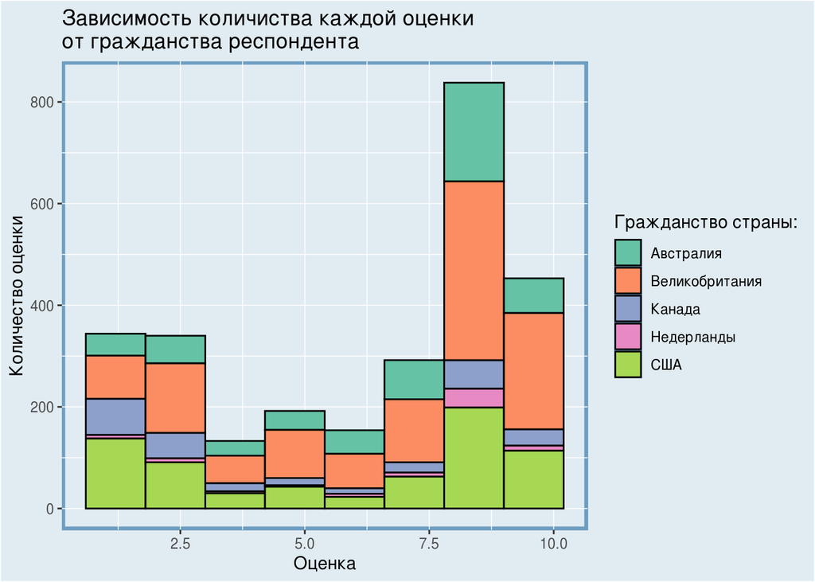

#### **Вывод по первому вопросу:**

На основе созданного графика можно сделать вывод, что граждане *США* чаще всего оставляют самые низкие оценки, равно как и граждане *Канады*. В свою очередь резиденты *Великобритании* и *Австралии* являются менее привередливы к деятельности компании и в большинстве случаев оставляют положительные отзывы. Пассажиры из *Нидерланд* в основном оценивают полёт в районе 7,7-8.5 баллов, что является показателем достаточно удовлетворённого полёта. Я бы рекомендовал своему заказчику уделить особое внимание пассажирам из *США* и *Канады*, более углублённо проанализировать их жалобы и недовольства, для того чтобы повысить рейтинг своей компании.

## **Второй вопрос.** Какой квартал года является самым популярным у пассажиров для перелёта?

Разные кварталы года приносят авиакомпаниям разную прибыль. Это может быть связано, к примеру, с праздничными днями или метеорологическими условиями локации. Основываясь на этой информации, управление заказчика сможет планировать уровень цен и всегда “держать руку на пульсе” спроса. Грамотный анализ данного графика позволит уменьшить стоимость в непопулярные кварталы и увеличить в пик популярности.

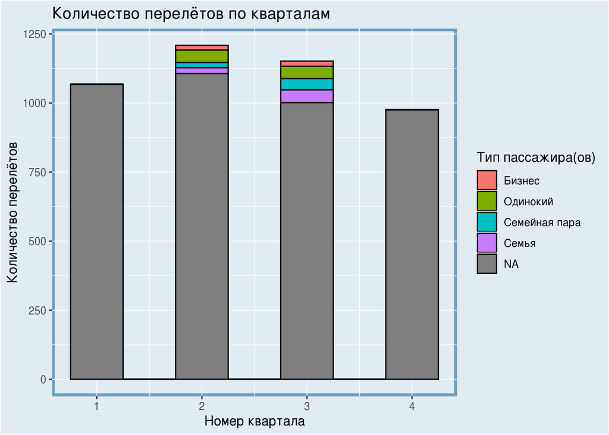

#### **Вывод по второму вопросу:**

На основе созданного графика можно сделать вывод, что 2 и 3 квартал являются наиболее популярными. К сожалению, собранные данные имеют заполненное поле type_traveller (тип пассажира) не для всех кварталов, поэтому мы получили такое распределение значений. Однако это не помешает нам сделать вывод о том, что в конце 1 квартала и в начале 4-го компания может менять ценовую политику ввиду различий спроса на авиаперевозки. Целесообразно незначительно увеличить цены в конце 1-го квартала и незначительно уменьшить их в начале 4-го. На основе типологии пассажиров, можно сделать вывод, что большинство пассажиров перелетают сами по себе. Однако в в 3 квартале семейные пары или семья с детьми перелетают гораздо чаще, чем во втором. Это может быть связано с порой летних каникул и летних отпусков. Соответственно, проведённый анализ выше может стать индикатором для дальнейших решений, принимаемых менеджментом фирмы.

## **Третий вопрос.** Какие авиафирмы находятся в топе рейтинга и как их общий рейтинг соотносится с их оценкой по цене/качеству?

Любая успешная компания должна держать “руку на пульсе”, когда речь заходит о деятельности конкурентов. Зачастую недооценённые фирмы-конкуренты добиваются больших успехов своими инновационными решениями в ведении бизнеса. Поэтому важно знать, какие фирмы составляют прямую конкуренцию авиакомпании, анализировать их рейтинг и предполагать причины таких показателей. Так как нас не интересуют искажённые данные, выборка данного исследования начинается от 15 отзывов. Совпадение высокой оценки с высоким показателем цены/качества подтверждает, что фирма смогла максимально эффективно распределить свои ресурсы и гарантировать низкие цены, подкреплённые достаточным уровнем сервиса. Именно поэтому целесообразно рассматривать те фирмы, которые обладают высокими показателями как общего рейтинга, так и показателя цены/качества. Для формирования столбцов используются медианные показатели всех оценок двух показателей рейтинга.

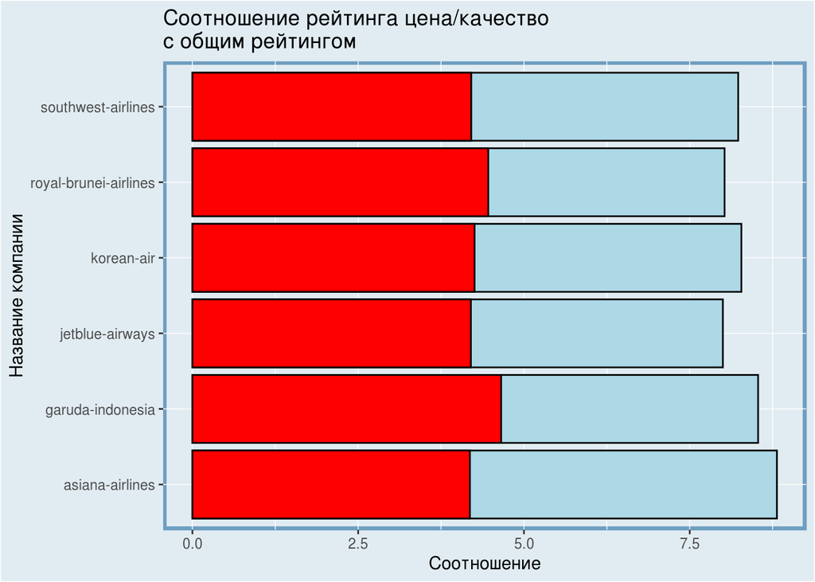

#### **Вывод по третьему вопросу:**

# Заключительный вывод проведённого анализа.

  Data Science Minor 2019-2020